# TO DO:

# The Effect of the timing smear from the Trigger Counters

We should check the effect of timing smear from the trigger counters. Top and Bottom Counter TDC distributions have tails. Not clear where they come from. We should see what the 11 peaks look like with events only in the sharp peaks. And also only in the tails…

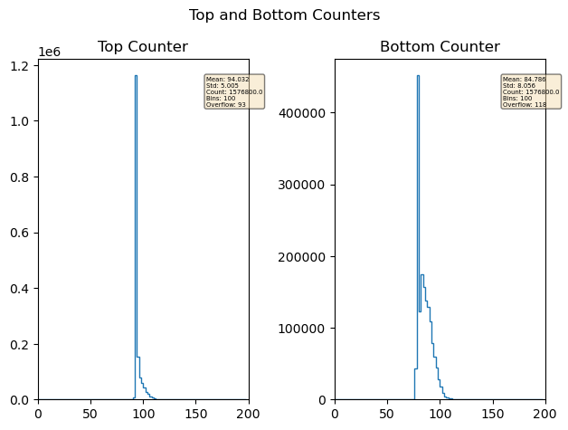

```python
mdfo_lead.reload()
mdfo_lead.keep4by4Events()
mdfo_lead.getCounterPlots()
```

**Peaks:**

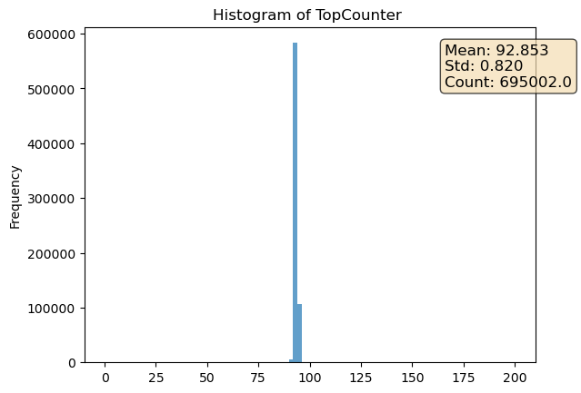

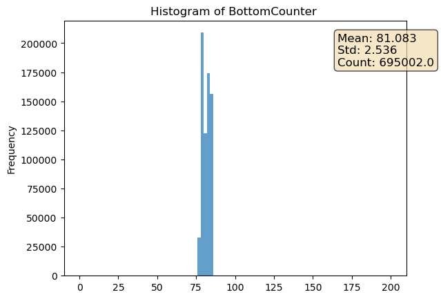

```python
mdfo_lead.reload()
mdfo_lead.keep4by4Events()
mdfo_lead.keepEvents("TopCounter", 95, "<=")
mdfo_lead.keepEvents("BottomCounter", 85, "<=")
mdfo_lead.getHistogram("TopCounter",nbins=100,range=(0,200))
mdfo_lead.getHistogram("BottomCounter",nbins=100,range=(0,200))
```

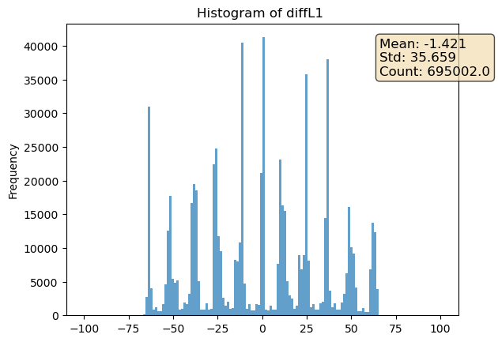

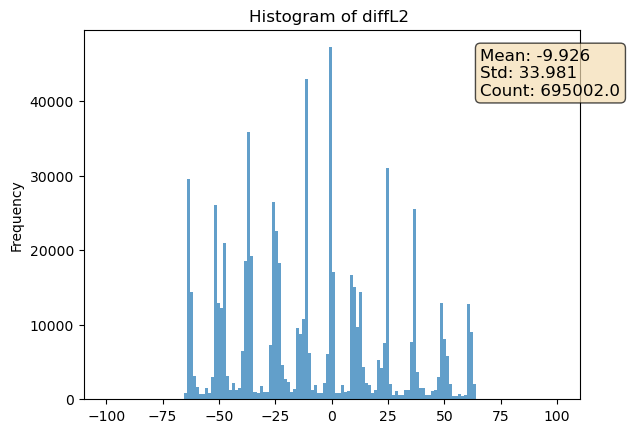

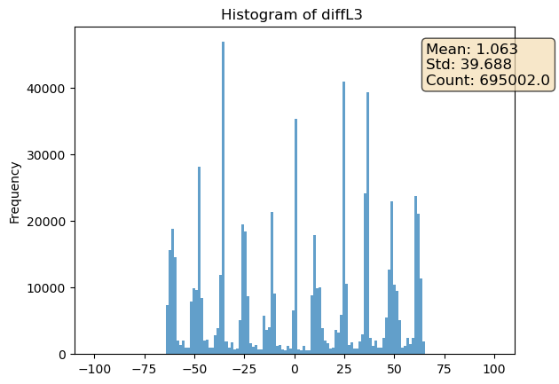

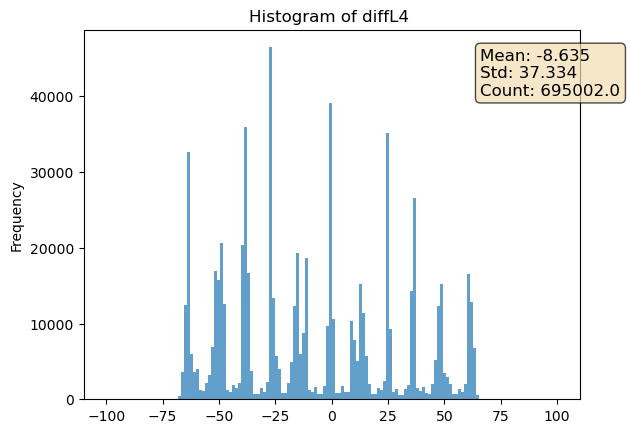

```python
mdfo_lead.getHistogram("diffL1",nbins=150,range=(-100,100))
mdfo_lead.getHistogram("diffL2",nbins=150,range=(-100,100))
mdfo_lead.getHistogram("diffL3",nbins=150,range=(-100,100))
mdfo_lead.getHistogram("diffL4",nbins=150,range=(-100,100))
```

**Tails:**

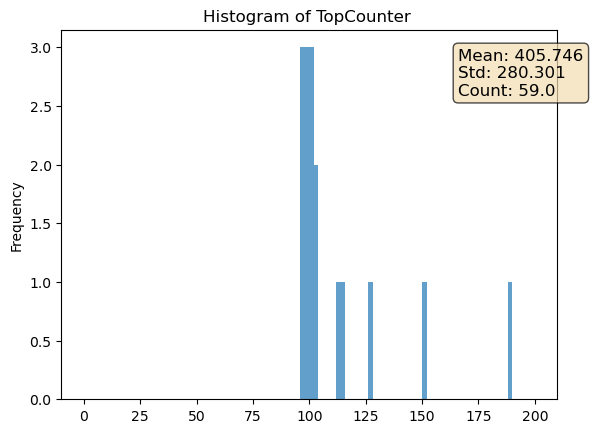

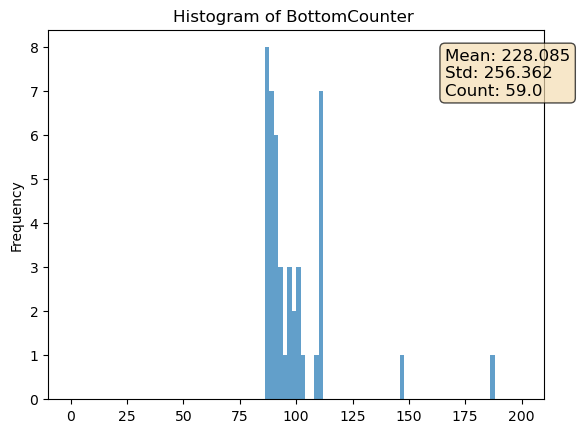

```python
mdfo_lead.reload()
mdfo_lead.keep4by4Events()
mdfo_lead.keepEvents("TopCounter", 95, ">")
mdfo_lead.keepEvents("BottomCounter", 85, ">")
mdfo_lead.getHistogram("TopCounter",nbins=100,range=(0,200))
mdfo_lead.getHistogram("BottomCounter",nbins=100,range=(0,200))
```

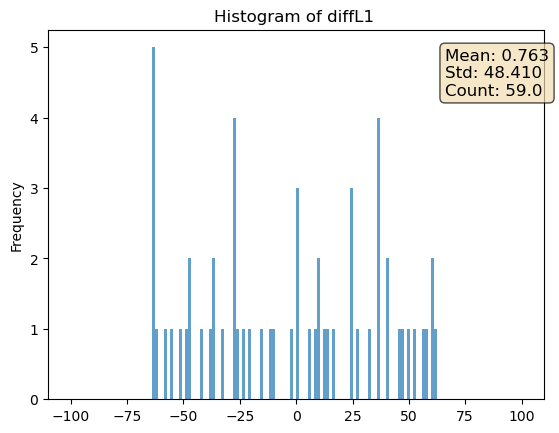

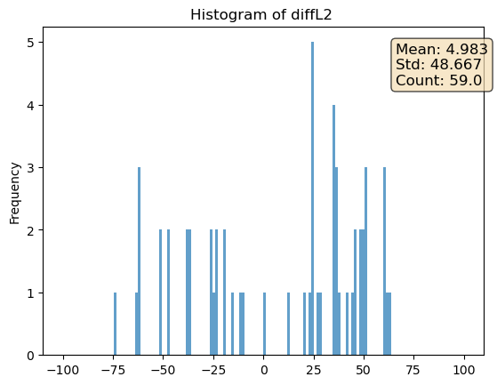

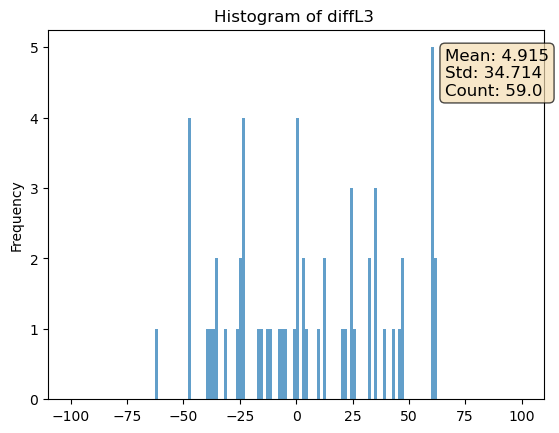

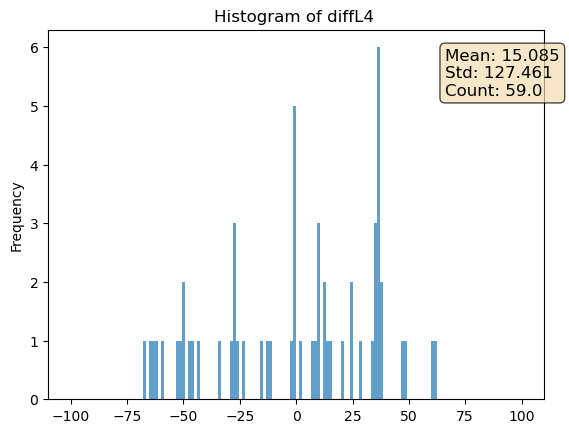

```python
mdfo_lead.getHistogram("diffL1",nbins=150,range=(-100,100))
mdfo_lead.getHistogram("diffL2",nbins=150,range=(-100,100))
mdfo_lead.getHistogram("diffL3",nbins=150,range=(-100,100))
mdfo_lead.getHistogram("diffL4",nbins=150,range=(-100,100))
```

The rate when the constraints of all fours layers hit and both counters having values in their tails are added falls dramatically.

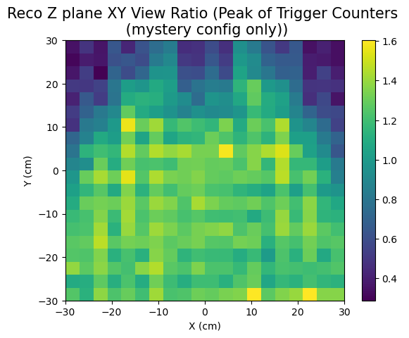

```python
mdfo_lead.reload()
mdfo_lead.keep4by4Events()
mdfo_lead.keepEvents("TopCounter", 95, "<=")
mdfo_lead.keepEvents("BottomCounter", 85, "<=")

mdfo_calib.reload()
mdfo_calib.keep4by4Events()

xx_lead, xx_calib = getSameSizeData(mdfo_lead, mdfo_calib, "xx1")
yy_lead, yy_calib = getSameSizeData(mdfo_lead, mdfo_calib, "yy1")

getRatioPlot([xx_lead,xx_calib],[yy_lead,yy_calib],bins=(20,20),axes=[-30,30],title="Peak of Trigger Counters \n (mystery config only)")
```

[figure not shown]

```python
mdfo_lead.reload()
mdfo_lead.keep4by4Events()
mdfo_lead.keepEvents("TopCounter", 95, "<=")
mdfo_lead.keepEvents("BottomCounter", 85, "<=")

mdfo_calib.reload()
mdfo_calib.keep4by4Events()

xx_lead, xx_calib = getSameSizeData(mdfo_lead, mdfo_calib, "xx1")
yy_lead, yy_calib = getSameSizeData(mdfo_lead, mdfo_calib, "yy1")

getRatioPlot([xx_lead,xx_calib],[yy_lead,yy_calib],bins=(20,20),axes=[-30,30],title="Peak of Trigger Counters + \n Artificial Constraint")
```

For both data sets - mystery and calib.

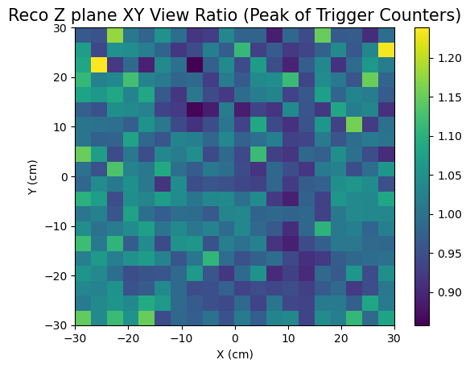

```python
mdfo_lead.reload()
mdfo_lead.keep4by4Events()
mdfo_lead.keepEvents("TopCounter", 95, "<=")
mdfo_lead.keepEvents("BottomCounter", 85, "<=")

mdfo_calib.reload()
mdfo_calib.keep4by4Events()
mdfo_calib.keepEvents("TopCounter", 95, "<=")
mdfo_calib.keepEvents("BottomCounter", 85, "<=")

xx_lead, xx_calib = getSameSizeData(mdfo_lead, mdfo_calib, "xx1")
yy_lead, yy_calib = getSameSizeData(mdfo_lead, mdfo_calib, "yy1")

getRatioPlot([xx_lead,xx_calib],[yy_lead,yy_calib],bins=(20,20),axes=[-30,30],title="Peak of Trigger Counters")
```

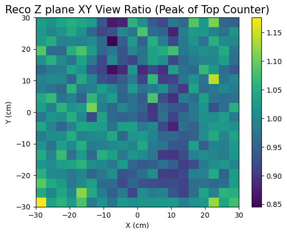

```python
mdfo_lead.reload()
mdfo_lead.keep4by4Events()
mdfo_lead.keepEvents("TopCounter", 95, "<=")
#mdfo_lead.keepEvents("BottomCounter", 85, "<=")

mdfo_calib.reload()
mdfo_calib.keep4by4Events()
mdfo_calib.keepEvents("TopCounter", 95, "<=")
#mdfo_calib.keepEvents("BottomCounter", 85, "<=")

xx_lead, xx_calib = getSameSizeData(mdfo_lead, mdfo_calib, "xx1")
yy_lead, yy_calib = getSameSizeData(mdfo_lead, mdfo_calib, "yy1")

getRatioPlot([xx_lead,xx_calib],[yy_lead,yy_calib],bins=(20,20),axes=[-30,30],title="Peak of Top Counter")
```

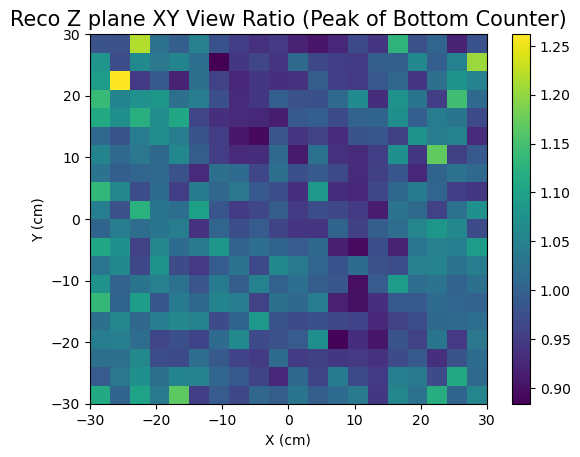

```python
mdfo_lead.reload()
mdfo_lead.keep4by4Events()
#mdfo_lead.keepEvents("TopCounter", 95, "<=")
mdfo_lead.keepEvents("BottomCounter", 85, "<=")

mdfo_calib.reload()
mdfo_calib.keep4by4Events()
#mdfo_calib.keepEvents("TopCounter", 95, "<=")
mdfo_calib.keepEvents("BottomCounter", 85, "<=")

xx_lead, xx_calib = getSameSizeData(mdfo_lead, mdfo_calib, "xx1")
yy_lead, yy_calib = getSameSizeData(mdfo_lead, mdfo_calib, "yy1")

getRatioPlot([xx_lead,xx_calib],[yy_lead,yy_calib],bins=(20,20),axes=[-30,30],title="Peak of Bottom Counter")
```

Analyzing the tails...

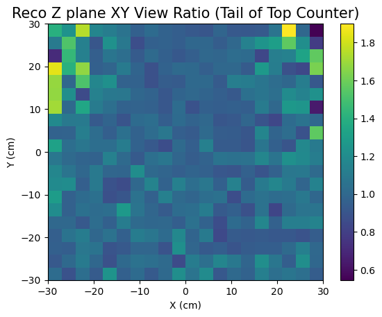

```python
mdfo_lead.reload()
mdfo_lead.keep4by4Events()
mdfo_lead.keepEvents("TopCounter", 95, ">")
#mdfo_lead.keepEvents("BottomCounter", 85, "<=")

mdfo_calib.reload()
mdfo_calib.keep4by4Events()
mdfo_calib.keepEvents("TopCounter", 95, ">")
#mdfo_calib.keepEvents("BottomCounter", 85, "<=")

xx_lead, xx_calib = getSameSizeData(mdfo_lead, mdfo_calib, "xx1")
yy_lead, yy_calib = getSameSizeData(mdfo_lead, mdfo_calib, "yy1")

getRatioPlot([xx_lead,xx_calib],[yy_lead,yy_calib],bins=(20,20),axes=[-30,30],title="Tail of Top Counter")
```

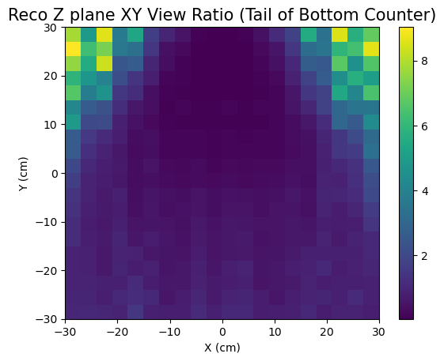

```python
mdfo_lead.reload()
mdfo_lead.keep4by4Events()
mdfo_lead.keepEvents("BottomCounter", 85, ">=")

mdfo_calib.reload()
mdfo_calib.keep4by4Events()
#mdfo_calib.keepEvents("TopCounter", 95, ">")
mdfo_calib.keepEvents("BottomCounter", 85, "<=")

xx_lead, xx_calib = getSameSizeData(mdfo_lead, mdfo_calib, "xx1")
yy_lead, yy_calib = getSameSizeData(mdfo_lead, mdfo_calib, "yy1")

getRatioPlot([xx_lead,xx_calib],[yy_lead,yy_calib],bins=(20,20),axes=[-30,30],title="Tail of Bottom Counter")
```

It seems that that the peaks contain most of the muon hits responsible for the tomogram. Getting rid of tails did not help in achieving better resolution.

# Analyzing the tomogram with physical constraints

The idea is to use the speed of light and other physical factors to refine the image. The muon rate will also be considered.

```python
mdfo_calib.reload()
mdfo_calib.keep4by4Events()
len(mdfo_calib.get("deadtime"))
```

```
1170773
```

```python
mdfo_lead.reload()
mdfo_lead.keep4by4Events()
len(mdfo_lead.get("deadtime"))
```

```
1576800
```

Let's use time to generate the plots.